# Intro to R

## Before we start

- Start RStudio & show console, scripts, environments, plots
- Code & workflow more reproducible if we document
- Goal no just do stuff but to do it so can replicate results

### r as calculator

```r
2+5
```

```
## [1] 7
```

```r
10/5
```

```
## [1] 2
```

To run code from script editor ctr+enter cmd+enter

How to comment & assign objects

```r
# this is a comment
# this is the second line
# assignment operator <-
```

```r
b <- 25 # = works but don't use
```

- Alt+- keyboard shortcut <-
- functions are canned scripts
- predefined functions - typical one sqrt()

```r
sqrt(b)
```

```
## [1] 5
```

```r
c <- sqrt(b)
c
```

```
## [1] 5
```

```r
round(3.14159)
```

```
## [1] 3
```

- Functions have arguments, some are called ‘options’:
- Arguements can be defaults.

```r
#use args() to find out args
args(round)
```

```
## function (x, digits = 0)
## NULL
```

```r
round(3.14159, digits = 2)
```

```
## [1] 3.14
```

## getting help

```r
?barplot
args(lm) #shows args
```

```
## function (formula, data, subset, weights, na.action, method = "qr",
##     model = TRUE, x = FALSE, y = FALSE, qr = TRUE, singular.ok = TRUE,
##     contrasts = NULL, offset, ...)
## NULL
```

```r
??geom_point # to get to package enabled functions
help.search("kruskal") #search for fuction must be installed
```

- Look in stackoverflow http://stackoverflow.com/questions/tagged/r

## Intro to R

- Explain script image. function, assignment operator, = for args, ## comments, $ operator, indentation

Creating objects in console, but lost when we close session.

```r
3 + 5
```

```
## [1] 8
```

More useful to assign values to objects.

```r
weight_kg <- 55 # object names sush as x, current_temp, subject_id, but cannot start with number, case sen
2.2 * weight_kg # can use object to convert to lbs
```

```
## [1] 121
```

```r
weight_kg <- 57.5 # can assign new value to the object
2.2 * weight_kg # shows different results
```

```
## [1] 126.5
```

```r
weight_lb <- 2.2 * weight_kg #can create new object from mult
weight_lb
```

```
## [1] 126.5
```

```r
weight_lb <- 100  # assign new value
weight_lb
```

```
## [1] 100
```

```r
#challenge
mass <- 47.5
age <- 122
(mass <- mass * 2.0)
```

```
## [1] 95
```

```r
(age <- age - 20)
```

```
## [1] 102
```

```r
(mass_index <- mass/age)
```

```
## [1] 0.9313725
```

## Creating functions

- define a function, return value from function

```r
fahr_to_kelvin <- function(temp){
  kelvin <- ((temp - 32) * (5/9)) +273.15
  return(kelvin)
}
```

```r
# using the function
fahr_to_kelvin(32)
```

```
## [1] 273.15
```

```r
fahr_to_kelvin(212)
```

```
## [1] 373.15
```

```r
kelvin_to_celsius <- function(temp){
  celsius <- temp - 273.15
  return(celsius)
}

#absolute zero in celsius
kelvin_to_celsius(0)
```

```
## [1] -273.15
```

## lets convert fahrenheit to celsius

```r
fahr_to_celsius <- function(temp) {
  temp_k <- fahr_to_kelvin(temp)
  result <- kelvin_to_celsius(temp_k)
  return(result)
}

#freezing point of water in celsius
fahr_to_celsius(32.0)
```

```
## [1] 0
```

## Vectors & data types

- vectors the workhorse of R
- basic data structure

```r
weights <- c(50, 60, 65, 82)
weights
```

```
## [1] 50 60 65 82
```

```r
animals <- c("mouse", "rat", "dog")
animals
```

```
## [1] "mouse" "rat"   "dog"
```

- functions that allow you to inspect a vector.

```r
length(weights)
```

```
## [1] 4
```

```r
length(animals)
```

```
## [1] 3
```

```r
class(weights)
```

```
## [1] "numeric"
```

```r
class(animals)
```

```
## [1] "character"
```

```r
str(weights)
```

```
##  num [1:4] 50 60 65 82
```

```r
str(animals)
```

```
##  chr [1:3] "mouse" "rat" "dog"
```

- the c() function - c is for combine - creates a vector.

```r
#combine
weights <- c(weights, 90)
weights <- c(30, weights)
weights
```

```
## [1] 30 50 60 65 82 90
```

- we just saw 2 of the 6 data types: character and numeric. Other 4 are: logical, integer, complex, raw
- vectors are one of many data structures in R: list, matrices, dataframe, factors

## Starting with data

- Let’s load our survey data.

```r
download.file("http://files.figshare.com/2236372/combined.csv", "data/portal_data_joined.csv")
surveys <- read.csv("data/portal_data_joined.csv")
```

- wrapping an assignment in parentheses will perform the assignment and display it at the same time.

```r
(surveys <- read.csv("data/portal_data_joined.csv"))
```

- use head to just see six rows

```r
head(surveys)
```

```
##   record_id month day year plot_id species_id sex hindfoot_length weight
## 1         1     7  16 1977       2         NL   M              32     NA
## 2        72     8  19 1977       2         NL   M              31     NA
## 3       224     9  13 1977       2         NL                  NA     NA
## 4       266    10  16 1977       2         NL                  NA     NA
## 5       349    11  12 1977       2         NL                  NA     NA
## 6       363    11  12 1977       2         NL                  NA     NA
##     genus  species   taxa plot_type
## 1 Neotoma albigula Rodent   Control
## 2 Neotoma albigula Rodent   Control
## 3 Neotoma albigula Rodent   Control
## 4 Neotoma albigula Rodent   Control
## 5 Neotoma albigula Rodent   Control
## 6 Neotoma albigula Rodent   Control
```

- look at the structure of the data

```r
str(surveys)
```

```
## 'data.frame':    34786 obs. of  13 variables:
##  $ record_id      : int  1 72 224 266 349 363 435 506 588 661 ...
##  $ month          : int  7 8 9 10 11 11 12 1 2 3 ...
##  $ day            : int  16 19 13 16 12 12 10 8 18 11 ...
##  $ year           : int  1977 1977 1977 1977 1977 1977 1977 1978 1978 1978 ...
##  $ plot_id        : int  2 2 2 2 2 2 2 2 2 2 ...
##  $ species_id     : Factor w/ 48 levels "AB","AH","AS",..: 16 16 16 16 16 16 16 16 16 16 ...
##  $ sex            : Factor w/ 6 levels "","F","M","P",..: 3 3 1 1 1 1 1 1 3 1 ...
##  $ hindfoot_length: int  32 31 NA NA NA NA NA NA NA NA ...
##  $ weight         : int  NA NA NA NA NA NA NA NA 218 NA ...
##  $ genus          : Factor w/ 26 levels "Ammodramus","Ammospermophilus",..: 13 13 13 13 13 13 13 13 13 13 ...
##  $ species        : Factor w/ 40 levels "albigula","audubonii",..: 1 1 1 1 1 1 1 1 1 1 ...
##  $ taxa           : Factor w/ 4 levels "Bird","Rabbit",..: 4 4 4 4 4 4 4 4 4 4 ...
##  $ plot_type      : Factor w/ 5 levels "Control","Long-term Krat Exclosure",..: 1 1 1 1 1 1 1 1 1 1 ...
```

- challenge - slide
- What is the class of object survey

## factors

- used to represent categorical variables
- Factors are stored as integers
- can only contain a pre-defined set values, known as levels
- alpha org

```r
sex <- factor(c("male", "female", "female", "male"))
levels(sex)
```

```
## [1] "female" "male"
```

```r
nlevels(sex)
```

```
## [1] 2
```

- sometimes order matters in factors (low med high)

```r
food <- factor(c("low", "high", "medium", "high", "low", "medium", "high"))
levels(food)
```

```
## [1] "high"   "low"    "medium"
```

```r
food <- factor(food, levels = c("low", "medium", "high"))
levels(food)
```

```
## [1] "low"    "medium" "high"
```

```r
#min(food)  ## doesn't work
```

```r
# ordered true
food <- factor(food, levels = c("low", "medium", "high"), ordered = TRUE)
levels(food)
```

```
## [1] "low"    "medium" "high"
```

```r
min(food)  ## works!
```

```
## [1] low
## Levels: low < medium < high
```

### converting factors

- use as.character(x)
- converting to numeric tricky

```r
f <- factor(c(1, 5, 10, 2))
as.numeric(f)  ## wrong! and there is no warning...
```

```
## [1] 1 3 4 2
```

```r
as.numeric(as.character(f))  ## works...
```

```
## [1]  1  5 10  2
```

```r
as.numeric(levels(f))[f]  ## The recommended way.
```

```
## [1]  1  5 10  2
```

```r
## Challenge slide

## How can you recreate this plot but by having 'control' being listed last
## instead of first?
exprmt <- factor(c("treat1", "treat2", "treat1", "treat3", "treat1", "control",
                   "treat1", "treat2", "treat3"))
table(exprmt)
```

```
## exprmt
## control  treat1  treat2  treat3
##       1       4       2       2
```

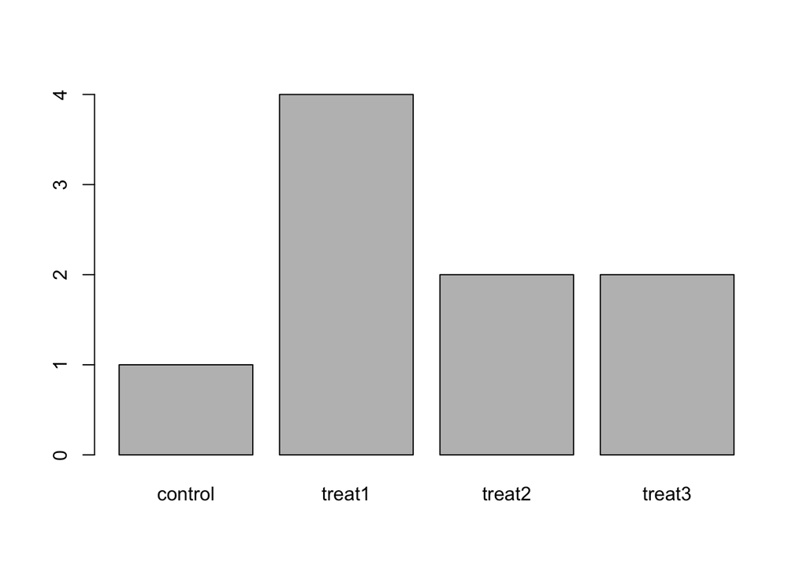

```r
barplot(table(exprmt))
```

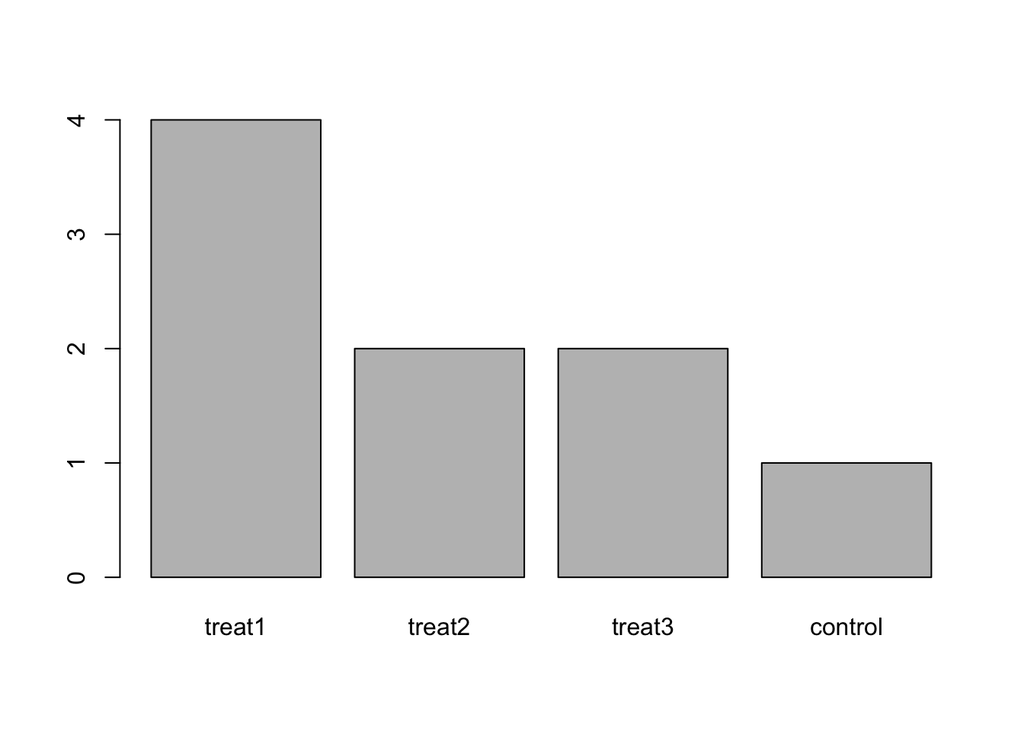

```r
##anser
exprmt <- factor(exprmt, levels = c("treat1", "treat2", "treat3", "control"))
barplot(table(exprmt))
```